# XU_Wenting Final Project: Fertility Rate & Life Expectancy

## 1.Introduction:

**Question**:

1. Is there a relationship between life expectancy and fertility rate?

   Do countries with higher life expectancies tend to have lower fertility rates?
2. Does this relationship differ across continents?
3. What are the characteristics of the trends in birth rate and life expectancy between France and China?

**Dataset introduction**: The raw data is downloaded from the website "World Bank Group Data"

```python
# 🚀 Run this cell first to set up environment!
import pandas as pd
import numpy as np
import matplotlib.pyplot as plt
```

## 2.Data Exploration

```python
# Import the dataset 1 (fertility rate)
fertility_row=pd.read_csv('Fertility_rate.csv')
fertility_row.info()
fertility_row.head()
fertility_row.keys()
```

```
<class 'pandas.core.frame.DataFrame'>
RangeIndex: 16928 entries, 0 to 16927
Data columns (total 43 columns):
 #   Column                  Non-Null Count  Dtype
---  ------                  --------------  -----
 0   STRUCTURE               16928 non-null  object
 1   STRUCTURE_ID            16928 non-null  object
 2   ACTION                  16928 non-null  object
 3   FREQ                    16928 non-null  object
 4   REF_AREA                16928 non-null  object
 5   INDICATOR               16928 non-null  object
 6   SEX                     16928 non-null  object
 7   AGE                     16928 non-null  object
 8   URBANISATION            16928 non-null  object
 9   UNIT_MEASURE            16928 non-null  object
```

[output cut: 35 more lines]

```
Index(['STRUCTURE', 'STRUCTURE_ID', 'ACTION', 'FREQ', 'REF_AREA', 'INDICATOR',
       'SEX', 'AGE', 'URBANISATION', 'UNIT_MEASURE', 'COMP_BREAKDOWN_1',
       'COMP_BREAKDOWN_2', 'COMP_BREAKDOWN_3', 'TIME_PERIOD', 'AGG_METHOD',
       'UNIT_TYPE', 'DECIMALS', 'DATABASE_ID', 'TIME_FORMAT', 'COMMENT_TS',
       'UNIT_MULT', 'DATA_SOURCE', 'OBS_CONF', 'OBS_VALUE', 'OBS_STATUS',
       'FREQ_LABEL', 'REF_AREA_LABEL', 'INDICATOR_LABEL', 'SEX_LABEL',
       'AGE_LABEL', 'URBANISATION_LABEL', 'UNIT_MEASURE_LABEL',
       'COMP_BREAKDOWN_1_LABEL', 'COMP_BREAKDOWN_2_LABEL',
       'COMP_BREAKDOWN_3_LABEL', 'AGG_METHOD_LABEL', 'UNIT_TYPE_LABEL',
       'DECIMALS_LABEL', 'DATABASE_ID_LABEL', 'TIME_FORMAT_LABEL',
       'UNIT_MULT_LABEL', 'OBS_STATUS_LABEL', 'OBS_CONF_LABEL'],
      dtype='object')
```

```python
# Since there are many columns are unnecessary for our analysis, we will drop them first.
choose_columns=['REF_AREA','REF_AREA_LABEL','TIME_PERIOD','OBS_VALUE']
fertility=fertility_row[choose_columns]
fertility=fertility.rename(columns={'OBS_VALUE':'Fertility_rate'})
fertility.head()
```

|  | REF_AREA | REF_AREA_LABEL | TIME_PERIOD | Fertility_rate |
| --- | --- | --- | --- | --- |
| 0 | VEN | Venezuela, RB | 2011 | 2.398 |
| 1 | VNM | Vietnam | 2011 | 1.927 |
| 2 | VIR | Virgin Islands (U.S.) | 2011 | 2.160 |
| 3 | PSE | West Bank and Gaza | 2011 | 4.305 |
| 4 | YEM | Yemen, Rep. | 2011 | 4.630 |

```python
# Import the dataset 2 (Life expectancy at birth)
expectancy_row=pd.read_csv('Life_expectancy_at_birth.csv')
expectancy_row.info()
expectancy_row.head()
expectancy_row.keys()
```

```
<class 'pandas.core.frame.DataFrame'>
RangeIndex: 16926 entries, 0 to 16925
Data columns (total 43 columns):
 #   Column                  Non-Null Count  Dtype
---  ------                  --------------  -----
 0   STRUCTURE               16926 non-null  object
 1   STRUCTURE_ID            16926 non-null  object
 2   ACTION                  16926 non-null  object
 3   FREQ                    16926 non-null  object
 4   REF_AREA                16926 non-null  object
 5   INDICATOR               16926 non-null  object
 6   SEX                     16926 non-null  object
 7   AGE                     16926 non-null  object
 8   URBANISATION            16926 non-null  object
 9   UNIT_MEASURE            16926 non-null  object
```

[output cut: 35 more lines]

```
Index(['STRUCTURE', 'STRUCTURE_ID', 'ACTION', 'FREQ', 'REF_AREA', 'INDICATOR',
       'SEX', 'AGE', 'URBANISATION', 'UNIT_MEASURE', 'COMP_BREAKDOWN_1',
       'COMP_BREAKDOWN_2', 'COMP_BREAKDOWN_3', 'TIME_PERIOD', 'AGG_METHOD',
       'UNIT_TYPE', 'DECIMALS', 'DATABASE_ID', 'TIME_FORMAT', 'COMMENT_TS',
       'UNIT_MULT', 'DATA_SOURCE', 'OBS_CONF', 'OBS_VALUE', 'OBS_STATUS',
       'FREQ_LABEL', 'REF_AREA_LABEL', 'INDICATOR_LABEL', 'SEX_LABEL',
       'AGE_LABEL', 'URBANISATION_LABEL', 'UNIT_MEASURE_LABEL',
       'COMP_BREAKDOWN_1_LABEL', 'COMP_BREAKDOWN_2_LABEL',
       'COMP_BREAKDOWN_3_LABEL', 'AGG_METHOD_LABEL', 'UNIT_TYPE_LABEL',
       'DECIMALS_LABEL', 'DATABASE_ID_LABEL', 'TIME_FORMAT_LABEL',
       'UNIT_MULT_LABEL', 'OBS_STATUS_LABEL', 'OBS_CONF_LABEL'],
      dtype='object')
```

```python
# Drop those unnecessary columns
expectancy=expectancy_row[choose_columns]
expectancy=expectancy.rename(columns={'OBS_VALUE':'Life_expectancy'})
expectancy.head()
```

|  | REF_AREA | REF_AREA_LABEL | TIME_PERIOD | Life_expectancy |
| --- | --- | --- | --- | --- |
| 0 | VEN | Venezuela, RB | 2011 | 73.090000 |
| 1 | VNM | Vietnam | 2011 | 73.713000 |
| 2 | VIR | Virgin Islands (U.S.) | 2011 | 78.317073 |
| 3 | PSE | West Bank and Gaza | 2011 | 73.557000 |
| 4 | YEM | Yemen, Rep. | 2011 | 67.412000 |

## 3.Data Cleaning

```python
#Combine two datasets
merge_df=pd.merge(fertility,expectancy,on=['REF_AREA','REF_AREA_LABEL','TIME_PERIOD'])
merge_df.shape
merge_df.info()
```

```
<class 'pandas.core.frame.DataFrame'>
RangeIndex: 16924 entries, 0 to 16923
Data columns (total 5 columns):
 #   Column           Non-Null Count  Dtype
---  ------           --------------  -----
 0   REF_AREA         16924 non-null  object
 1   REF_AREA_LABEL   16924 non-null  object
 2   TIME_PERIOD      16924 non-null  int64
 3   Fertility_rate   16924 non-null  float64
 4   Life_expectancy  16924 non-null  float64
dtypes: float64(2), int64(1), object(2)
memory usage: 661.2+ KB
```

```python
#The merged dataframe looks better than before with the correct data type, however we still need to take a look.
merge_df.head()
```

|  | REF_AREA | REF_AREA_LABEL | TIME_PERIOD | Fertility_rate | Life_expectancy |
| --- | --- | --- | --- | --- | --- |
| 0 | VEN | Venezuela, RB | 2011 | 2.398 | 73.090000 |
| 1 | VNM | Vietnam | 2011 | 1.927 | 73.713000 |
| 2 | VIR | Virgin Islands (U.S.) | 2011 | 2.160 | 78.317073 |
| 3 | PSE | West Bank and Gaza | 2011 | 4.305 | 73.557000 |
| 4 | YEM | Yemen, Rep. | 2011 | 4.630 | 67.412000 |

```python
# It would be great if we can rename the columns' names, especially for the first two columns. And the decimals should be controlled in two.
merge_df=merge_df.rename(columns={'REF_AREA':'Country_Code','REF_AREA_LABEL':'Country_name','TIME_PERIOD':'Year'})
merge_df['Fertility_rate']=merge_df['Fertility_rate'].round(2)
merge_df['Life_expectancy']=merge_df['Life_expectancy'].round(2)
merge_df.head()
merge_df.describe()
```

|  | Year | Fertility_rate | Life_expectancy |
| --- | --- | --- | --- |
| count | 16924.000000 | 16924.000000 | 16924.000000 |
| mean | 1991.540357 | 3.843688 | 64.734579 |
| std | 18.467636 | 1.956731 | 11.080732 |
| min | 1960.000000 | 0.590000 | 10.990000 |
| 25% | 1976.000000 | 2.060000 | 57.657500 |
| 50% | 1992.000000 | 3.350000 | 67.085000 |
| 75% | 2008.000000 | 5.680000 | 72.912500 |
| max | 2023.000000 | 8.860000 | 86.370000 |

```python
continent=pd.read_csv('https://gist.githubusercontent.com/stevewithington/20a69c0b6d2ff846ea5d35e5fc47f26c/raw/13716ceb2f22b5643ce5e7039643c86a0e0c6da6/country-and-continent-codes-list-csv.csv')
final=pd.merge(merge_df,continent[['Three_Letter_Country_Code','Continent_Name']],left_on='Country_Code',right_on='Three_Letter_Country_Code',how='left').drop(columns=['Three_Letter_Country_Code'])
final.head()
```

|  | Country_Code | Country_name | Year | Fertility_rate | Life_expectancy | Continent_Name |
| --- | --- | --- | --- | --- | --- | --- |
| 0 | VEN | Venezuela, RB | 2011 | 2.40 | 73.09 | South America |
| 1 | VNM | Vietnam | 2011 | 1.93 | 73.71 | Asia |
| 2 | VIR | Virgin Islands (U.S.) | 2011 | 2.16 | 78.32 | North America |
| 3 | PSE | West Bank and Gaza | 2011 | 4.30 | 73.56 | Asia |
| 4 | YEM | Yemen, Rep. | 2011 | 4.63 | 67.41 | Asia |

```python
# Check if there's NA in the dataset
final.isna().sum()
```

```
Country_Code          0
Country_name          0
Year                  0
Fertility_rate        0
Life_expectancy       0
Continent_Name     3200
dtype: int64
```

```python
#There's some NA for the continent, we need to check what it is.
final[final['Continent_Name'].isna()].head()

final[final['Continent_Name'].isna()]['Country_name'].unique()
```

```
array(['Eastern & Southern Africa', 'Western & Central Africa',
       'Arab World', 'Caribbean small states',
       'Central Europe and the Baltics', 'Early-demographic dividend',
       'East Asia & Pacific',
       'East Asia & Pacific (excluding high income)',
       'East Asia & Pacific (IDA & IBRD)', 'Euro area',
       'Europe & Central Asia',
       'Europe & Central Asia (excluding high income)',
       'Sub-Saharan Africa (excluding high income)',
       'Sub-Saharan Africa (IDA & IBRD)', 'Upper middle income', 'World',
       'Kosovo', 'Channel Islands', 'Sub-Saharan Africa',
       'Europe & Central Asia (IDA & IBRD)', 'South Asia (IDA & IBRD)',
       'Post-demographic dividend', 'Pre-demographic dividend',
       'Small states', 'South Asia', 'European Union',
       'Fragile and conflict affected situations',
       'Heavily indebted poor countries (HIPC)', 'High income',
       'IBRD only', 'IDA & IBRD total', 'IDA blend', 'IDA only',
       'Pacific island small states', 'IDA total',
       'Late-demographic dividend', 'Latin America & Caribbean',
       'Latin America & Caribbean (excluding high income)',
       'Latin America & Caribbean (IDA & IBRD)',
       'Least developed countries: UN classification',
       'Low & middle income', 'Low income', 'Lower middle income',
       'Middle East, North Africa, Afghanistan & Pakistan',
       'Middle East, North Africa, Afghanistan & Pakistan (excluding high income)',
       'Middle East, North Africa, Afghanistan & Pakistan (IDA & IBRD)',
       'Middle income', 'North America', 'OECD members',
       'Other small states'], dtype=object)
```

```python
#Above are not specific country but more like a region, in order to avoid the situation like "Arab World (ARB)" spans Africa and Asia, making it difficult to categorize into a single group.
#I would suggest we drop these NA data

clean=final.dropna(subset=['Continent_Name'])
clean.isna().sum()
```

```
Country_Code       0
Country_name       0
Year               0
Fertility_rate     0
Life_expectancy    0
Continent_Name     0
dtype: int64
```

## 4.Data Analysis

### 4.1 Average fertility rate and life expectancy trend in the whole world

```python
trend=clean.groupby('Year')[['Fertility_rate','Life_expectancy']].mean().round(2)
print(trend)
```

```
      Fertility_rate  Life_expectancy
Year
1960            5.40            54.97
1961            5.39            55.45
1962            5.39            55.96
1963            5.40            56.20
1964            5.35            56.76
...              ...              ...
2019            2.53            73.06
2020            2.48            72.51
2021            2.45            71.79
2022            2.40            73.12
2023            2.37            73.82

[64 rows x 2 columns]
```

As we can see from the below data, as year goes on, the average fertility rate decreases, while the life expectancy increases. We can combine with the plot later to better analyse the trend.

### 4.2 Which five countries have the fastest declining fertility rates from 1960 to 2023?

```python
country_year_fertility=clean.groupby(['Country_name','Year'])['Fertility_rate'].mean().unstack()
country_year_fertility['Difference']=country_year_fertility[2023]-country_year_fertility[1960]
#We need to filter those countries with positive rate of change in fertility
country_year_fertility.nsmallest(5,'Difference')
```

| Year Country_name | 1960 | 1961 | 1962 | 1963 | 1964 | 1965 | 1966 | 1967 | 1968 | 1969 | ... | 2015 | 2016 | 2017 | 2018 | 2019 | 2020 | 2021 | 2022 | 2023 | Difference |
| --- | --- | --- | --- | --- | --- | --- | --- | --- | --- | --- | --- | --- | --- | --- | --- | --- | --- | --- | --- | --- | --- |
| Iran, Islamic Rep. | 7.52 | 7.46 | 7.40 | 7.32 | 7.24 | 7.22 | 7.21 | 7.19 | 7.12 | 7.01 | ... | 2.02 | 2.05 | 2.02 | 1.92 | 1.77 | 1.70 | 1.71 | 1.70 | 1.70 | -5.82 |
| Kuwait | 7.22 | 7.25 | 7.25 | 7.28 | 7.29 | 7.31 | 7.34 | 7.33 | 7.28 | 7.18 | ... | 2.03 | 2.06 | 2.16 | 2.12 | 2.08 | 2.03 | 2.15 | 1.55 | 1.52 | -5.70 |
| Brunei Darussalam | 7.32 | 7.18 | 7.03 | 6.89 | 6.77 | 6.65 | 6.51 | 6.37 | 6.20 | 6.01 | ... | 1.95 | 1.92 | 1.88 | 1.85 | 1.82 | 1.80 | 1.78 | 1.76 | 1.75 | -5.57 |
| St. Vincent and the Grenadines | 7.25 | 7.16 | 7.03 | 6.92 | 6.83 | 6.74 | 6.64 | 6.53 | 6.42 | 6.28 | ... | 2.13 | 2.06 | 1.94 | 1.90 | 1.86 | 1.83 | 1.81 | 1.79 | 1.78 | -5.47 |
| Bahrain | 7.26 | 7.23 | 7.18 | 7.14 | 7.09 | 7.03 | 6.94 | 6.84 | 6.71 | 6.57 | ... | 2.11 | 2.04 | 1.98 | 1.91 | 1.84 | 1.86 | 1.85 | 1.84 | 1.82 | -5.44 |

5 rows × 65 columns

### 4.3 Which country has the longest life expectancy from 1960 to 2023?

```python
max_expectancy=clean.groupby('Year')['Life_expectancy'].idxmax()
yearly_top_life=clean.loc[max_expectancy]
yearly_top_life
```

|  | Country_Code | Country_name | Year | Fertility_rate | Life_expectancy | Continent_Name |
| --- | --- | --- | --- | --- | --- | --- |
| 17156 | ISL | Iceland | 1960 | 4.29 | 74.04 | Europe |
| 16952 | NLD | Netherlands | 1961 | 3.22 | 73.65 | Europe |
| 16858 | ISL | Iceland | 1962 | 3.98 | 73.72 | Europe |
| 14792 | SMR | San Marino | 1963 | 2.40 | 73.59 | Europe |
| 15812 | FRO | Faroe Islands | 1964 | 3.98 | 73.86 | Europe |
| ... | ... | ... | ... | ... | ... | ... |
| 3697 | MCO | Monaco | 2019 | 2.40 | 86.15 | Europe |
| 4401 | MCO | Monaco | 2020 | 2.38 | 86.09 | Europe |
| 4377 | HKG | Hong Kong SAR, China | 2021 | 0.77 | 85.53 | Asia |
| 4062 | MCO | Monaco | 2022 | 2.11 | 85.75 | Europe |
| 5621 | MCO | Monaco | 2023 | 2.11 | 86.37 | Europe |

64 rows × 6 columns

### 4.4 Is there a relationship bewteen fertility rate and life expectancy?

```python
correlation_total=clean['Fertility_rate'].corr(clean['Life_expectancy'])
print(correlation_total)
```

```
-0.8451785290019683
```

The correlation coefficient is approximately -0.85, indicating a strong negative relationship between fertility rates and life expectancy. However, it is crucial to remember that correlation does not imply causation. A lower fertility rate does not, in itself, increase life expectancy. Instead, we must consider confounding factors such as improvements in public health, increased access to education, economic development, and robust social security systems, which often drive both trends simultaneously. We will have more discusion in the conclusion part.

### 4.5 Does this relationship differ across different continents?

```python
correlation_by_continent=clean.groupby('Continent_Name').apply(
    lambda x: x['Fertility_rate'].corr(x['Life_expectancy']),
    include_groups=False)
print(correlation_by_continent)
```

```
Continent_Name
Africa          -0.740371
Asia            -0.755459
Europe          -0.611558
North America   -0.838278
Oceania         -0.735868
South America   -0.869869
dtype: float64
```

As we can see from the data, South America (-0.87) and North America (-0.84) have the strongest negative correlation. This indicates that in the Americas, the trend of declining fertility rates as life expectancy increases is highly consistent and closely linked.

However, Europe (-0.61) has the weakest negative correlation. We can speculate on the reasons behind this: Many European countries (such as Germany and Italy) transitioned into a stage of low fertility and high life expectancy quite early. Once life expectancy reaches a very high level (e.g., above 80 years), fertility rates may have already stabilized at a very low point. Consequently, the 'pace of change' between the two is no longer as synchronized as it is in developing regions.

### 4.6 Compare data between France and China

France is a typical developped country while China is quick developping country nowadays. We analysed them from two questions:

-In which year did life expectancy first exceed 70 years?

```python
#Need to filter data whose life expectancy over 70 years old.
milestone_70=clean[clean['Life_expectancy']>70].groupby('Country_name')['Year'].min()
print(milestone_70.loc[['France','China']])
```

```
Country_name
France    1961
China     1995
Name: Year, dtype: int64
```

France reached a life expectancy of 70 years in 1961, while China achieved this in 1995. The gap is 34 years, which reflect the gap bewteen a developped country and a developping country.

```python
compare=clean[clean['Country_name'].isin(['France','China'])].groupby(['Country_name','Year'])['Fertility_rate'].mean().unstack()
compare['Difference']=compare[2000]-compare[1970]
compare
```

| Year Country_name | 1960 | 1961 | 1962 | 1963 | 1964 | 1965 | 1966 | 1967 | 1968 | 1969 | ... | 2015 | 2016 | 2017 | 2018 | 2019 | 2020 | 2021 | 2022 | 2023 | Difference |
| --- | --- | --- | --- | --- | --- | --- | --- | --- | --- | --- | --- | --- | --- | --- | --- | --- | --- | --- | --- | --- | --- |
| China | 4.45 | 3.86 | 6.08 | 7.51 | 6.67 | 6.60 | 6.31 | 5.81 | 6.51 | 6.18 | ... | 1.67 | 1.77 | 1.80 | 1.54 | 1.50 | 1.24 | 1.12 | 1.03 | 1.00 | -4.45 |
| France | 2.85 | 2.87 | 2.89 | 2.89 | 2.87 | 2.84 | 2.80 | 2.75 | 2.69 | 2.62 | ... | 1.96 | 1.92 | 1.89 | 1.87 | 1.86 | 1.83 | 1.84 | 1.79 | 1.66 | -0.66 |

2 rows × 65 columns

Due to the one-child policy, China's fertility rate decreased 4.45, while France only decreased 0.66.

## 5. Data Visualization

### 5.1 The Global Scatter Plot

```python
import seaborn as sns
```

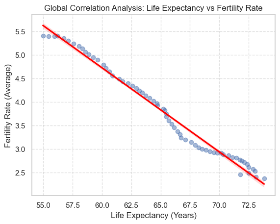

```python
sns.regplot(data=trend, x='Life_expectancy', y='Fertility_rate',
            scatter_kws={'alpha':0.5},
            line_kws={'color':'red'})
plt.title('Global Correlation Analysis: Life Expectancy vs Fertility Rate')
plt.xlabel('Life Expectancy (Years)')
plt.ylabel('Fertility Rate (Average)')
plt.grid(True, linestyle='--', alpha=0.6)
plt.savefig('global_correlation_plot.png')
```

### 5.2 Top 10 countries who's fertility rate decline tho most from 1960 to 2023

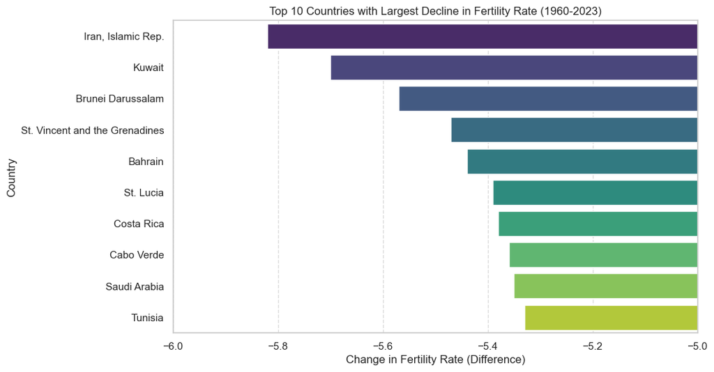

```python
top_10 =country_year_fertility.nsmallest(10,'Difference')
plot_data = top_10.sort_values(by='Difference')
plt.figure(figsize=(10, 6))

sns.barplot(data=plot_data, x='Difference', y='Country_name', hue='Country_name',palette='viridis')
plt.title('Top 10 Countries with Largest Decline in Fertility Rate (1960-2023)')
plt.xlabel('Change in Fertility Rate (Difference)')
plt.ylabel('Country')
plt.xlim(-6,-5)
plt.grid(axis='x', linestyle='--', alpha=0.7)

plt.show()
```

### 5.3 Country with the Highest Life Expectancy by Year (1960-2023)

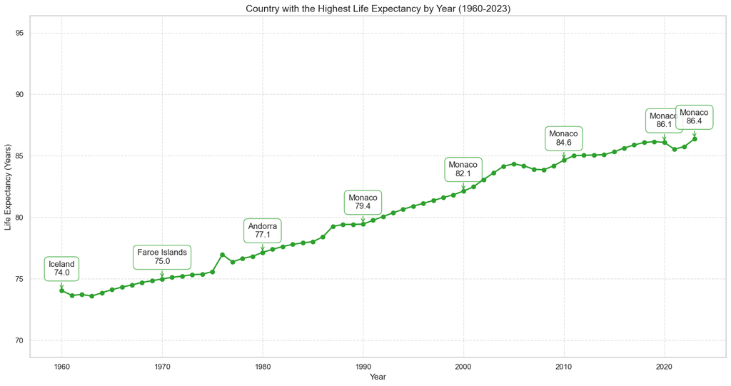

```python
plt.figure(figsize=(15, 8))

plt.plot(yearly_top_life['Year'], yearly_top_life['Life_expectancy'],
         marker='o', color='#2ca02c', linewidth=2, markersize=6)

#To avoid making the image too cluttered, we add labels every 10 years.
for i, row in yearly_top_life.iterrows():
    if row['Year'] % 10 == 0 or row['Year'] == 2023:
        plt.annotate(
            f"{row['Country_name']}\n{row['Life_expectancy']:.1f}",
            xy=(row['Year'], row['Life_expectancy']),
            xytext=(0, 20),
            textcoords='offset points',
            ha='center',
            va='bottom',
            bbox=dict(boxstyle='round,pad=0.5', fc='white', ec='#2ca02c', alpha=0.8),
            arrowprops=dict(arrowstyle='->', color='#2ca02c')
        )

plt.title('Country with the Highest Life Expectancy by Year (1960-2023)', fontsize=14)
plt.xlabel('Year', fontsize=12)
plt.ylabel('Life Expectancy (Years)', fontsize=12)
plt.grid(True, linestyle='--', alpha=0.6)
plt.ylim(yearly_top_life['Life_expectancy'].min() - 5, yearly_top_life['Life_expectancy'].max() + 10)

plt.tight_layout()
plt.show()
```

### 5.4 Correlation Comparison: Life Expectancy vs Fertility Rate by Continent

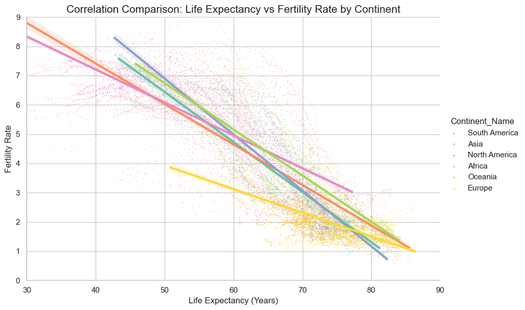

```python
sns.set_theme(style="whitegrid")

g = sns.lmplot(
    data=clean,
    x='Life_expectancy',
    y='Fertility_rate',
    hue='Continent_Name',
    palette='Set2',
    scatter_kws={'alpha':0.2, 's':1}, # let the countries become smaller in order to avoid messy
    line_kws={'linewidth':3},
    height=6, aspect=1.5
)


plt.title('Correlation Comparison: Life Expectancy vs Fertility Rate by Continent', fontsize=15)
plt.xlabel('Life Expectancy (Years)', fontsize=12)
plt.ylabel('Fertility Rate', fontsize=12)
plt.xlim(30, 90)
plt.ylim(0, 9)

leg = g.legend
for lh in leg.legend_handles:
    lh.set_alpha(1)

plt.show()
```

### 5.5 The Global Migration: Aging Warning Quadrant

```python
years = sorted(clean['Year'].unique())
continents = clean['Continent_Name'].unique()
colors = plt.get_cmap('Set2', len(continents))
color_map = {cont: colors(i) for i, cont in enumerate(continents)}

fig, ax = plt.subplots(figsize=(12, 8))

def setup_axes():
    ax.set_xlim(30, 90)
    ax.set_ylim(0, 9)
    ax.axhline(2.1, color='black', linestyle='--', alpha=0.5, lw=1)
    ax.axvline(70, color='black', linestyle='--', alpha=0.5, lw=1)

    #Healthy life: 70 years old
    #Standard fertility rate: 2.1

    ax.text(35, 8.5, 'Traditional\n(High Birth, Low Life)', alpha=0.2, fontsize=12, fontweight='bold')
    ax.text(75, 8.5, 'Expansion\n(High Birth, High Life)', alpha=0.2, fontsize=12, fontweight='bold')
    ax.text(75, 0.5, 'Aging Warning\n(Low Birth, High Life)', alpha=0.4, fontsize=12, fontweight='bold', color='red')
    ax.text(35, 0.5, 'Transition\n(Low Birth, Low Life)', alpha=0.2, fontsize=12, fontweight='bold')

    ax.set_xlabel('Life Expectancy (Years)', fontsize=12)
    ax.set_ylabel('Fertility Rate (Children per Woman)', fontsize=12)

def update(frame):
    ax.clear()
    setup_axes()
    current_year = years[frame]
    data_year = clean[clean['Year'] == current_year]

    for cont in continents:
        sub = data_year[data_year['Continent_Name'] == cont]
        ax.scatter(sub['Life_expectancy'], sub['Fertility_rate'],
                   s=100, alpha=0.6, label=cont, edgecolors='white', color=color_map[cont])

    for country in ['China', 'France']:
        c_data = data_year[data_year['Country_name'] == country]
        if not c_data.empty:
            ax.annotate(country, (c_data['Life_expectancy'].iloc[0], c_data['Fertility_rate'].iloc[0]),
                        xytext=(5, 5), textcoords='offset points', fontweight='bold')

    ax.set_title(f'The Global Migration: Aging Warning Quadrant ({int(current_year)})', fontsize=15, pad=20)
    ax.legend(loc='upper right', title="Continents")

ani = FuncAnimation(fig, update, frames=range(0, len(years), 5), interval=300)

plt.close()
HTML(ani.to_jshtml())
```

[figure not shown]

### 5.6 Comparison of France and China

#### 5.6.1 The March of Time: Evolution of Life & Fertility (1960-2023)

```python
import matplotlib.pyplot as plt
from matplotlib.animation import FuncAnimation
from IPython.display import HTML

france_data = clean[clean['Country_name'] == 'France'].sort_values('Year')
china_data = clean[clean['Country_name'] == 'China'].sort_values('Year')
years = france_data['Year'].unique()

fig, ax1 = plt.subplots(figsize=(12, 6))
ax2 = ax1.twinx()

# Set the limit for X and Y (Life_expectancy 40-80, Fertility_rate 1-7)
ax1.set_xlim(years.min(), years.max())
ax1.set_ylim(30, 90)
ax2.set_ylim(0, 8)

# China: Red, France: Blue
# Solid line means Life_expectancy，dotted line means Fertility_rate
line_c_life, = ax1.plot([], [], color='tab:red', linestyle='-', label='China: Life Expectancy', lw=2)
line_c_fert, = ax2.plot([], [], color='tab:red', linestyle='--', label='China: Fertility Rate', lw=2)
line_f_life, = ax1.plot([], [], color='tab:blue', linestyle='-', label='France: Life Expectancy', lw=2)
line_f_fert, = ax2.plot([], [], color='tab:blue', linestyle='--', label='France: Fertility Rate', lw=2)

ax1.set_xlabel('Year')
ax1.set_ylabel('Life Expectancy (Solid Line)')
ax2.set_ylabel('Fertility Rate (Dashed Line)')
plt.title('The March of Time: Evolution of Life & Fertility (1960-2023)')

lines = [line_c_life, line_c_fert, line_f_life, line_f_fert]
labels = [l.get_label() for l in lines]
ax1.legend(lines, labels, loc='center right')

def update(frame):
    current_year = years[frame]
    c_sub = china_data[china_data['Year'] <= current_year]
    f_sub = france_data[france_data['Year'] <= current_year]

    line_c_life.set_data(c_sub['Year'], c_sub['Life_expectancy'])
    line_c_fert.set_data(c_sub['Year'], c_sub['Fertility_rate'])
    line_f_life.set_data(f_sub['Year'], f_sub['Life_expectancy'])
    line_f_fert.set_data(f_sub['Year'], f_sub['Fertility_rate'])

    return line_c_life, line_c_fert, line_f_life, line_f_fert

ani = FuncAnimation(fig, update, frames=range(0, len(years), 5), interval=300, blit=True)

plt.close()
HTML(ani.to_jshtml())
```

[figure not shown]

#### 5.6.2 Demographic Crossroads: The Life-Fertility Trajectory

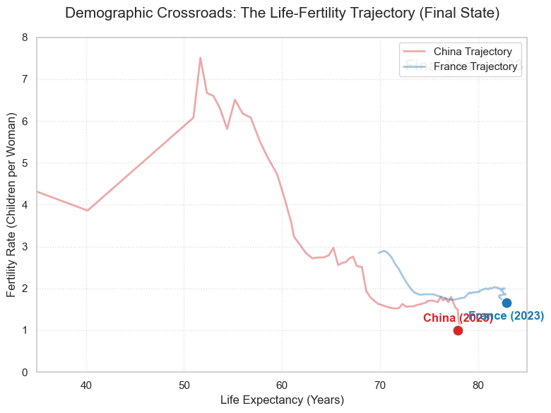

```python
fig, ax = plt.subplots(figsize=(8, 6))

ax.set_xlim(35, 85)
ax.set_ylim(0, 8)

# China: Red, France: Blue
# Solid line means Life_expectancy，dotted line means Fertility_rate
ax.plot(china_data['Life_expectancy'], china_data['Fertility_rate'],
        color='tab:red', alpha=0.4, lw=2, label='China Trajectory')
ax.scatter(china_data['Life_expectancy'].iloc[-1], china_data['Fertility_rate'].iloc[-1],
           color='tab:red', s=120, edgecolors='white', zorder=5)

ax.plot(france_data['Life_expectancy'], france_data['Fertility_rate'],
        color='tab:blue', alpha=0.4, lw=2, label='France Trajectory')
ax.scatter(france_data['Life_expectancy'].iloc[-1], france_data['Fertility_rate'].iloc[-1],
           color='tab:blue', s=120, edgecolors='white', zorder=5)

last_year = int(china_data['Year'].max())
ax.text(0.75, 0.9, f'Final Year: {last_year}', transform=ax.transAxes,
        fontsize=16, fontweight='bold', alpha=0.3)

ax.text(china_data['Life_expectancy'].iloc[-1], china_data['Fertility_rate'].iloc[-1] + 0.2,
        'China (2023)', color='tab:red', fontweight='bold', ha='center')
ax.text(france_data['Life_expectancy'].iloc[-1], france_data['Fertility_rate'].iloc[-1] - 0.4,
        'France (2023)', color='tab:blue', fontweight='bold', ha='center')

ax.set_xlabel('Life Expectancy (Years)', fontsize=12)
ax.set_ylabel('Fertility Rate (Children per Woman)', fontsize=12)
plt.title('Demographic Crossroads: The Life-Fertility Trajectory (Final State)', fontsize=15, pad=20)
ax.grid(True, linestyle=':', alpha=0.6)
ax.legend(loc='upper right')

plt.tight_layout()
plt.show()
```

## 6. Conclusion

### 6.1 Relationship between fertility rate and life expectancy

Based on the data and visualizations provided, here is a concise analysis of the relationship between fertility rate and life expectancy:

-Analysis of Demographic Correlation

1. Strong Negative Correlation (-0.85): There is a significant inverse relationship between the two variables. As life expectancy increases—indicating improvements in healthcare, nutrition, and stability—fertility rates tend to decline sharply. This reflects a global shift where increased child survival rates often lead to families choosing to have fewer children.
2. Variations Across Continents: The correlation coefficient varies by continent (e.g., South America at -0.87 vs. Europe at -0.61). These differences exist because:

   Development Stages: Europe has already reached a "plateau" where both life expectancy and fertility are relatively stable at low levels, weakening the linear correlation.

   Pace of Transition: In regions like South America and Asia, the transition from high-fertility/low-life-expectancy to the modern model is happening more rapidly, making the correlation appear much stronger during this volatile shift.
3. Correlation vs. Causality: While the link is statistically strong, it is not necessarily a direct causation. This analysis does not account for critical "confounding variables" such as:

   Education Levels: Higher education for women is one of the strongest predictors of lower fertility.

   Social Security: In nations with robust pension systems, the cultural need for many children as "old-age security" diminishes.

   Economic Opportunity: Urbanization and the rising cost of child-rearing influence these trends independently of health improvements.

### 6.2 Comparison between France and China

Based on the data visualized in "March of Time" and "Demographic Crossroads" charts, as well as historical contexts, here is an analysis of the demographic evolution of China and France:

1. Contrasting Trends in Fertility and Longevity China's Volatile Transformation: China’s data exhibits a high-intensity, rapid transition. Life expectancy surged from below 40 years in 1960 to nearly 80 years by 2023, while fertility rates crashed from peaks above 6.0 to approximately 1.0.

   France's Gradual Maturity: France shows the characteristics of a mature, developed economy. Its life expectancy has followed a steady, linear climb from 70 to over 80 years, while its fertility rate has remained remarkably stable, hovering near the replacement level (around 1.8–2.0) for decades before a slight recent dip.
2. The Great Convergence: China’s Rapid Health Gains Overcoming Historical Turmoil: At the start of the 1960s, China’s life expectancy was significantly lower than France's due to the aftermath of decades of conflict, including the Sino-Japanese War and the Chinese Civil War, followed by internal social upheavals.

   France’s "Social Safety Net" Stability: In contrast, France’s decline has been extremely gradual and stable. This is largely attributed to France's robust pro-family social policies, including generous child subsidies, state-funded childcare, and strong labor protections for parents, which have prevented the "fertility collapse" seen in East Asia.